# 13.Decision Tree_Q slides

## Decision Tree

### Da-Wei Chiang

## 大綱

- 決策樹的訴求
- 決策樹的演算法
- 演算法`ID3`介紹
  - `Entropy`
  - `Infomation Gain`
- 其他的決策樹
- `Decision Tree Implement`

## 決策樹的訴求

- 如條件判斷結構一樣的樹狀圖
- 看圖就一目瞭然的知道要分哪一類
- 透過檢查整個決策樹，使用測試資料找到決策樹中葉子節點所對應的類別標籤

## 決策樹的訴求

[figure not shown]

## 決策樹的演算法

- `ID3`
- `C4.5`
- `CART`
- `...etc`

## `ID3`介紹

## 資訊滳`(Entropy)`

- 衡量一個空間中資料分布的均勻程度。資料分布的越均勻，滳就越大；反之滳就越小。
- 衡量單一資料的不確定性機率可用$-log (p_i)$
- 但由於資料可能會有多種情況，因此在計算整體資料的不確定性時。應該計算整體不確定性$-log(p_i)$的期望值$E$，也就是資訊滳。其公式如下 $$E[-log p_i] = \sum\limits_{i=1}^n(p_i\ log\ p_i)$$
- 資訊滳是對於事物不確性的衡量標準

## 資訊增益`(Infomation Gain)`

- 對於每一項特徵項目計算平均資訊期望值，假定某特徵項目I有兩個特徵值(p1、p2)，其平均資訊期望值計算如下
  - 先計算p1在整體資料S中佔的比率$p1\over S$
  - 之後計算在p1的情況下S1類的次數C1及p1的情況下S2類的次數C2
  - 有了p1情況下各類別次數之後計算p1情況的資訊滳，即$p1\_I(S1,S2) = I(C1,C2) = -{{C1}\over p1}log{{C1}\over p1}-{{C2}\over p1}log{{C2}\over p1}$
  - 以同樣的步驟計算特徵值p2的資訊滳$p2\_I(S1,S2)$
- 對於該特徵類別有了兩個特徵值的類別資訊滳之後即可計算平均資訊期望值，即 $$E(特徵項目) = {p1\over S} \times p1\_I(S1,S2)+{p1\over S}\times p1\_I(S1,S2)$$
- 資訊增益 $$Information\ Gain(特徵項目) = S_I(S1,S2) - E(特徵項目)$$

## 範例

[figure not shown]

## 第一層 - `Class`

[figure not shown]

## 第一層 - `Gender`

[figure not shown]

## 第一層 - 各個欄位`Information Gain`

[figure not shown]

- 因為`Travel Cost`的`Information Gain`較大，因此由`Travel Cost`為`root`節點開始切

## 切完第一層後的資料集

[figure not shown]

## 第一層的決策樹

[figure not shown]

## 切完`Travel Cost = Cheap`下的`Attribute`

[figure not shown]

## 第二層 重複第一層的計算, 得到的`Informatino Gain`

[figure not shown]

## 第二層的決策樹

[figure not shown]

## 切完`Travel Cost = Cheap、Gender = Female`下的`Attribute`

[figure not shown]

## 第三層 重複第前兩層的計算, 得到的`Informatino Gain`

[figure not shown]

- 當`Information Gain`一樣時，可隨意挑選分割點。假定我們以`Car Ownership`做分割

## 最後的決策樹

[figure not shown]

## 其他的決策樹

- `C4.5`
  - 資訊增益`(Information Gain)`改為資訊增益率`(Gain Ratio)`作為分割的依據
- `CART`
  - `CART`是一種`Binary Tree`,即每一刀切下去的結果不是「是」就是「否」

## Decision Tree Implement

```
from sklearn.tree import DecisionTreeClassifier  #引用

DecisionTree_Variable = DecisionTreeClassifier(criterion, max_depth, min_samples_split)
DecisionTree_Variable.fit(X_train, Y_train)

#criterion: 指定切割方式, 可設定gini或entropy
#max_depth: 決策術的最大深度, 預設為None.
#min_samples_split: 分割內部節點的最小樣本數, 預設為2
```

## 範例 - 使用`sklearn`內建`Wine`資料集

```
from sklearn import datasets  #引用

Wine_data_Variable = datasets.load_wine()  #使用wine資料集

data = Wine_data_Variable.data
target = Wine_data_Variable.target
```

## `Wine`資料集介紹

- 葡萄酒資料集
  - 178筆資料、13個欄位

```python
# 資料及介紹
from sklearn import datasets  #引用

Wine = datasets.load_wine()  #使用wine資料集
print(Wine.keys())
print(Wine.DESCR)
```

```
dict_keys(['data', 'target', 'frame', 'target_names', 'DESCR', 'feature_names'])
.. _wine_dataset:

Wine recognition dataset
------------------------

**Data Set Characteristics:**

    :Number of Instances: 178 (50 in each of three classes)
    :Number of Attributes: 13 numeric, predictive attributes and the class
    :Attribute Information:
 		- Alcohol
 		- Malic acid
 		- Ash
		- Alcalinity of ash
 		- Magnesium
		- Total phenols
 		- Flavanoids
 		- Nonflavanoid phenols
 		- Proanthocyanins
		- Color intensity
 		- Hue
 		- OD280/OD315 of diluted wines
 		- Proline

    - class:
            - class_0
            - class_1
            - class_2

    :Summary Statistics:

    ============================= ==== ===== ======= =====
                                   Min   Max   Mean     SD
    ============================= ==== ===== ======= =====
    Alcohol:                      11.0  14.8    13.0   0.8
    Malic Acid:                   0.74  5.80    2.34  1.12
    Ash:                          1.36  3.23    2.36  0.27
    Alcalinity of Ash:            10.6  30.0    19.5   3.3
    Magnesium:                    70.0 162.0    99.7  14.3
```

[output cut: 41 more lines]

```
  Tech. Rep. no. 92-02, (1992), Dept. of Computer Science and Dept. of
  Mathematics and Statistics, James Cook University of North Queensland.
  (Also submitted to Technometrics).

  The data was used with many others for comparing various
  classifiers. The classes are separable, though only RDA
  has achieved 100% correct classification.
  (RDA : 100%, QDA 99.4%, LDA 98.9%, 1NN 96.1% (z-transformed data))
  (All results using the leave-one-out technique)

  (2) S. Aeberhard, D. Coomans and O. de Vel,
  "THE CLASSIFICATION PERFORMANCE OF RDA"
  Tech. Rep. no. 92-01, (1992), Dept. of Computer Science and Dept. of
  Mathematics and Statistics, James Cook University of North Queensland.
  (Also submitted to Journal of Chemometrics).
```

## Training Model

```python
## 範例
from sklearn.datasets import load_wine
from sklearn.tree import DecisionTreeClassifier
from sklearn.model_selection import train_test_split
from sklearn import metrics

wine = load_wine()
wine_X = wine.data
wine_Y = wine.target


train_X, test_X, train_Y, test_Y = train_test_split(wine_X, wine_Y, test_size = 0.3)

DecisionTree = DecisionTreeClassifier()
Wine_Classification = DecisionTree.fit(train_X, train_Y)
predicted = Wine_Classification.predict(test_X)

accuracy = Wine_Classification.score(test_X, test_Y)

print(predicted)
print(accuracy)
```

```
[2 2 2 2 1 1 2 1 1 0 2 1 0 0 1 2 1 0 0 2 2 0 1 1 0 2 0 0 2 0 0 1 0 0 0 0 1
 1 2 1 1 1 1 1 0 1 1 2 2 1 2 0 0 2]
0.9814814814814815
```

## 繪製`DecisionTree`

```
from sklearn.tree import plot_tree
import matplotlib.pyplot as plt

plot_tree(DecisionTree_Model, filled, feature_names, class_names)
```

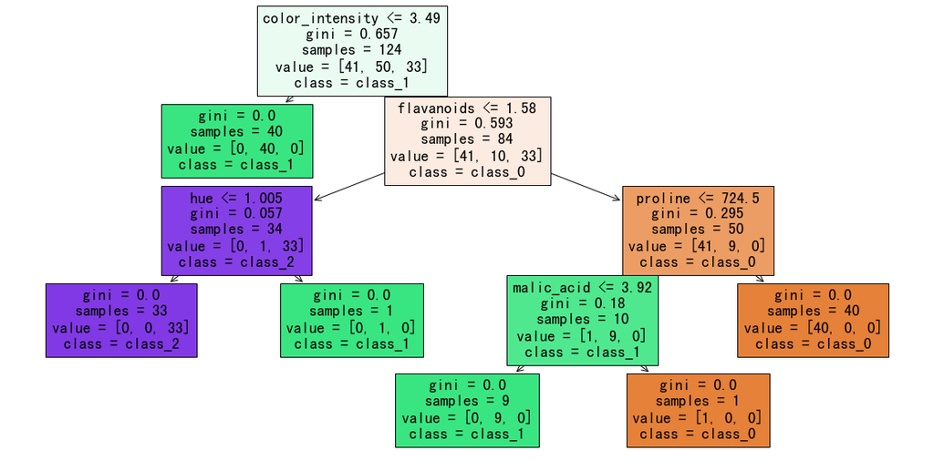

```python
## 範例

plt.figure(figsize=(20,10))
plot_tree(DecisionTree, filled=True, feature_names=wine.feature_names, class_names=wine.target_names)
plt.show()
```

```python
## 設定決策樹參數

## 深度為2的樹
DecisionTree = DecisionTreeClassifier(max_depth=2)
Wine_Classification = DecisionTree.fit(train_X, train_Y)
predicted = Wine_Classification.predict(test_X)

accuracy = Wine_Classification.score(test_X, test_Y)

print(accuracy) ##欠擬合

## 深度為3的樹
DecisionTree = DecisionTreeClassifier(max_depth=3)
Wine_Classification = DecisionTree.fit(train_X, train_Y)
predicted = Wine_Classification.predict(test_X)

accuracy = Wine_Classification.score(test_X, test_Y)

print(accuracy)
```

```
0.8888888888888888
0.9444444444444444
```

## 使用網格搜尋`GridSearchCV`找尋最佳參數

```python
## 範例
from sklearn.model_selection import GridSearchCV

params = {'max_depth': [3, 5, 7, 9, 11]}
CV = GridSearchCV(DecisionTreeClassifier(), params)
CV.fit(train_X, train_Y)

print('最佳參數', CV.best_params_)

y_pred = CV.predict(test_X)
print(CV.score(test_X, test_Y))
```

```
最佳參數 {'max_depth': 7}
0.9814814814814815
```

## 練習 - 資料集下載

- [醫療保險金資料集](https://drive.google.com/file/d/1Bn7fk3fYmdMj3N2n-3BQuyrVjmnTZigp/view?usp=sharing)
- 請使用該資料集練習`Training Decision Tree`

## 決策迴歸樹

- 傳統的決策樹是一種`classification`的模型
- 經改良過後的決策樹也能進行數值型資料的預測
- 決策迴歸樹
  - 選擇一個對目標欄位較有影響的特徵進行切割
  - 根據所選的特徵分割數據
  - 繼續選擇特徵進行切割
  - 預測.每個葉節點都會給出一個預測值. 這個值是所有訓練樣本的平均值

## Decision Tree Regression Implement

```
from sklearn.tree import DecisionTreeRegressor  #引用

DecisionTree_Variable = DecisionTreeRegressor(criterion, max_depth, min_samples_split)
DecisionTree_Variable.fit(X_train, Y_train)

#criterion: 指定切割方式, 預設為mse
#max_depth: 決策術的最大深度, 預設為None.
#min_samples_split: 分割內部節點的最小樣本數, 預設為2
```

```
X test [[27]
 [26]
 [33]
 [25]]
y pred [32. 22. 34. 22.]
```

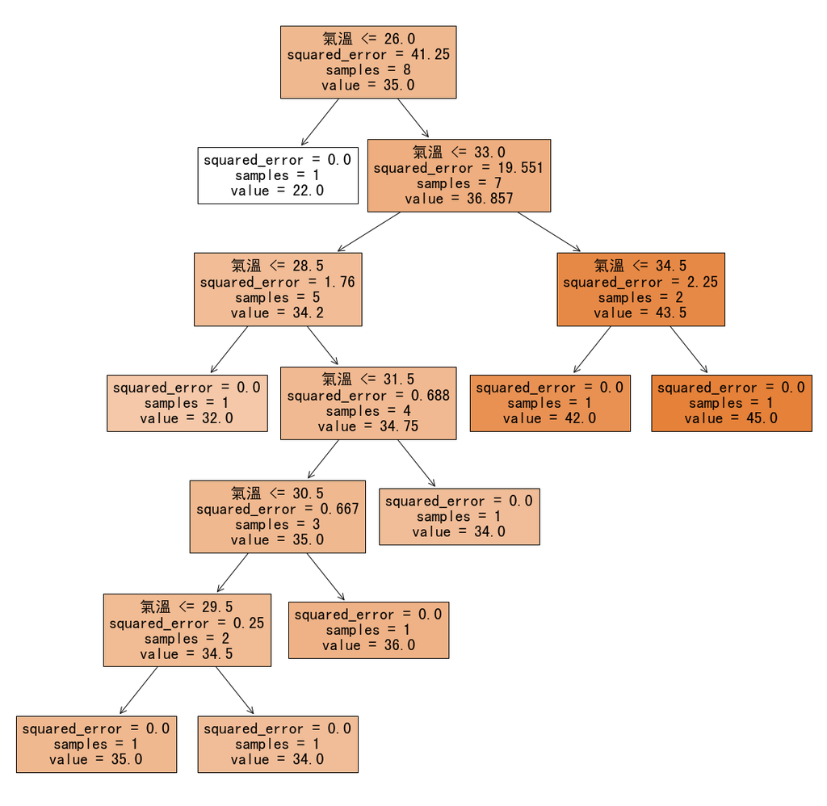

```python
## 範例

from sklearn.tree import DecisionTreeRegressor
from sklearn.model_selection import train_test_split
import numpy as np

X = np.arange(24, 36)   #氣溫
Y = np.array([22, 25, 28, 32, 32, 35, 34, 36, 34, 38, 42, 45])  #冰品銷售量

X = X.reshape(-1, 1)  #轉換為sklearn模型指定維度

X_train, X_test, y_train, y_test = train_test_split(X, Y, test_size=0.3)

tree = DecisionTreeRegressor()
tree.fit(X_train, y_train)

y_pred = tree.predict(X_test)
print('X test', X_test)
print('y pred', y_pred)

plt.figure(figsize=(20,20))
plot_tree(tree, filled=True, feature_names=['氣溫'])
plt.show()
```

## 迴歸模型評估

```
from sklearn.metrics import mean_squared_error ## MSE - 越小越好
```

```python
## 範例 - 承上題練習題
from sklearn.metrics import mean_squared_error

print('MSE = ', mean_squared_error(y_test, y_pred))
```

[output not shown]

## 範例 - 使用`sklearn`內建`boston`波士頓房價資料集

```
from sklearn import datasets  #引用

Boston_data_Variable = datasets.load_boston()  #使用boston資料集

data = Boston_data_Variable.data
target = Boston_data_Variable.target
```

## `Boston`資料集介紹

- 波士頓房價資料集
  - 506筆資料、13個欄位

```python
# 資料及介紹
from sklearn import datasets  #引用

Boston = datasets.load_boston()  #使用Boston資料集
print(Boston.keys())
print(Boston.DESCR)
```

```
dict_keys(['data', 'target', 'feature_names', 'DESCR', 'filename', 'data_module'])
.. _boston_dataset:

Boston house prices dataset
---------------------------

**Data Set Characteristics:**

    :Number of Instances: 506

    :Number of Attributes: 13 numeric/categorical predictive. Median Value (attribute 14) is usually the target.

    :Attribute Information (in order):
        - CRIM     per capita crime rate by town
        - ZN       proportion of residential land zoned for lots over 25,000 sq.ft.
        - INDUS    proportion of non-retail business acres per town
        - CHAS     Charles River dummy variable (= 1 if tract bounds river; 0 otherwise)
        - NOX      nitric oxides concentration (parts per 10 million)
        - RM       average number of rooms per dwelling
        - AGE      proportion of owner-occupied units built prior to 1940
        - DIS      weighted distances to five Boston employment centres
        - RAD      index of accessibility to radial highways
        - TAX      full-value property-tax rate per $10,000
        - PTRATIO  pupil-teacher ratio by town
        - B        1000(Bk - 0.63)^2 where Bk is the proportion of black people by town
        - LSTAT    % lower status of the population
        - MEDV     Median value of owner-occupied homes in $1000's

    :Missing Attribute Values: None

    :Creator: Harrison, D. and Rubinfeld, D.L.

This is a copy of UCI ML housing dataset.
https://archive.ics.uci.edu/ml/machine-learning-databases/housing/


This dataset was taken from the StatLib library which is maintained at Carnegie Mellon University.

The Boston house-price data of Harrison, D. and Rubinfeld, D.L. 'Hedonic
prices and the demand for clean air', J. Environ. Economics & Management,
vol.5, 81-102, 1978.   Used in Belsley, Kuh & Welsch, 'Regression diagnostics
...', Wiley, 1980.   N.B. Various transformations are used in the table on
pages 244-261 of the latter.

The Boston house-price data has been used in many machine learning papers that address regression
problems.

.. topic:: References

   - Belsley, Kuh & Welsch, 'Regression diagnostics: Identifying Influential Data and Sources of Collinearity', Wiley, 1980. 244-261.
   - Quinlan,R. (1993). Combining Instance-Based and Model-Based Learning. In Proceedings on the Tenth International Conference of Machine Learning, 236-243, University of Massachusetts, Amherst. Morgan Kaufmann.
```

[output not shown]

## 練習

- 請使用波士頓房價資料集.
  - 建構決策迴歸樹預測波士頓房價
  - 並評估其結果